# Mining genetic, transcriptomic and imaging data in Parkinson’s disease - 3

Manuel Tognon

8/10/2021

# Functional interpretation

Differential expression analysis on putamen and caudate dopamine uptake values. The below differential expression analysis test for genes showing a differential expression by DaTscan putamen and caudate values, showed by the individuals participating to PPMI baseline RNA-seq. After the differential expression analysis we’ll be carried out an enrichment analysis to recover the biological pathways potentially perturbed by differentially expressed genes.

R packages required:

- DESeq2
- ggplot2
- limma
- fgsea
- org.Hs.eg.db
- ReactomePA
- data.table
- RNOmni

```r
if(!require("BiocManager", character.only = TRUE))
{
  install.packages("BiocManager")
  if(!require("BiocManager", character.only = TRUE))
  {
    stop("BiocManager package not found")
  }
}
```

```
## Bioconductor version 3.12 (BiocManager 1.30.10), ?BiocManager::install for help
```

```
## Bioconductor version '3.12' is out-of-date; the current release version '3.13'
##   is available with R version '4.1'; see https://bioconductor.org/install
```

```r
if(!require("DESeq2", character.only = TRUE))
{
  BiocManager::install("DESeq2")
  if(!require("DESeq2", character.only = TRUE))
  {
    stop("DESeq2 package not found")
  }
}
```

```r
if(!require("ggplot2", character.only = TRUE))
{
  install.packages("ggplot2")
  if(!require("ggplot2", character.only = TRUE))
  {
    stop("ggplot2 package not found")
  }
}
if(!require("limma", character.only = TRUE))
{
  BiocManager::install("limma")
  if(!require("limma", character.only = TRUE))
  {
    stop("limma package not found")
  }
}
if(!require("fgsea", character.only = TRUE))
{
  BiocManager::install("fgsea")
  if(!require("fgsea", character.only = TRUE))
  {
    stop("fgsea package not found")
  }
}
if(!require("org.Hs.eg.db", character.only = TRUE))
{
  BiocManager::install("org.Hs.eg.db")
  if(!require("org.Hs.eg.db", character.only = TRUE))
  {
    stop("org.Hs.eg.db")
  }
}
if(!require("ReactomePA", character.only = TRUE))
{
  BiocManager::install("ReactomePA")
  if(!require("ReactomePA", character.only = TRUE))
  {
    stop("ReactomePA package not found")
  }
}
```

```
## ReactomePA v1.34.0  For help: https://guangchuangyu.github.io/ReactomePA
##
## If you use ReactomePA in published research, please cite:
## Guangchuang Yu, Qing-Yu He. ReactomePA: an R/Bioconductor package for reactome pathway analysis and visualization. Molecular BioSystems 2016, 12(2):477-479
```

```r
if(!require("data.table", character.only = TRUE))
{
  install.packages("data.table")
  if(!require("data.table", character.only = TRUE))
  {
    stop("data.table package not found")
  }
}
if(!require("RNOmni", character.only = TRUE))
{
  install.packages("RNOmni")
  if(!require("RNOmni", character.only = TRUE))
  {
    stop("RNOmni package not found")
  }
}
if(!require("STRINGdb", character.only = TRUE))
{
  install.packages("STRINGdb")
  if(!require("STRINGdb", character.only = TRUE))
  {
    stop("STRINGdb package not found")
  }
}
```

Import the libraries previously installed.

```r
library(DESeq2)
library(ggplot2)
library(limma)
library(fgsea)
library(org.Hs.eg.db)
library(ReactomePA)
library(data.table)
library(RNOmni)
library(STRINGdb)
library(httr)
```

Let’s begin by importing data RNA-seq counts and phenotype data!

```r
counts <- read.table("data/transcriptomic/PPMI-RNA-seq_baseline_rawCounts.txt")
metadata <- read.csv("data/pheno/PPMI-baseline_pheno.csv")
```

Samples are identified by complex names, let’s recover their PATNO…

```r
getid <- function(s){
  patno <- unlist(strsplit(s, ".", fixed = T))[4]
  return(patno)
}
samples.ids <- colnames(counts)
samples.ids.new <- sapply(samples.ids, getid)
names(samples.ids.new) <- NULL  # remove old names
colnames(counts) <- samples.ids.new
head(counts)
```

```
##                    3083 3478 3281 3586  3603  4103  4107 3815  3118  3637  3020
## ENSG00000000003.10   26   23   23   24    13    59    18   11     0     5    12
## ENSG00000000005.5     4    1   23    2     0     6     1    0     2     0     1
## ENSG00000000419.8   970  928  445  579   632  1872   417  635   170   646  1138
## ENSG00000000457.9  1668 1129  937 1076  1715  4113  1140 1762   728  1737  2109
## ENSG00000000460.12  424  382  338  342   437   850   428  701   179   509   588
## ENSG00000000938.8  5860 5323 6665 9100 11038 22702 11843 9176 10076 12728 13529
##                    4078  3951  3516  3760  3818  3305 3614  3768  3309 3452
## ENSG00000000003.10   31    24    10    32    12    31   10    16    19   10
## ENSG00000000005.5    20     0     1     1     0     0    0     8     9    2
## ENSG00000000419.8   298   882  1249  1280   337  1365  689   435   676  358
## ENSG00000000457.9   704  2204  2770  2912  1279  2305 1216  1137  1829 1094
## ENSG00000000460.12  245   710   730   915   457   778  524   377   474  357
## ENSG00000000938.8  6100 11502 19676 20913 12790 14959 7016 17450 12929 9097
##                    3151 3819  4032 3008  3816  3421 3433  3522  3269  3166 4109
## ENSG00000000003.10    5    8     9   21    23    15    9     9    46    21    8
## ENSG00000000005.5     0    1     1    0     0     0    0     0     0     1    0
## ENSG00000000419.8   300  444   800  991   532   707  575   639  1256  1090  653
## ENSG00000000457.9   687 1310  1462 1631  1798  1804 1557  1468  2976  2412 1085
## ENSG00000000460.12  280  409   630  494   655   563  484   465   695   752  334
## ENSG00000000938.8  8938 9206 13759 6455 10977 10419 8203 12044 17670 11679 7763
##                     4056  4020  3439 3072  3960 3216 4058  4030  3332  3570
## ENSG00000000003.10    14     1    24   12    24   11   11     2    28     9
## ENSG00000000005.5      0     2     0    0     3    0    3     0     8     0
## ENSG00000000419.8    682   491  1420  403   734  704  395   558   514  1050
## ENSG00000000457.9   1716  1100  2174 1084  1384 1563  893  1416  1320  2165
## ENSG00000000460.12   619   333   841  322   436  522  359   450   481   764
## ENSG00000000938.8  13119 10843 10973 9387 14891 8416 7998 12401 10921 17674
##                    3503  3635  3000  3237  4104 3211 4038 3320 3089 3366  3279
## ENSG00000000003.10   43    11    39     9     6    6   35   17   52   18     6
## ENSG00000000005.5     7     0     4     0     0    2    0    0    0   15     4
## ENSG00000000419.8   516   752   565   581   826  582  734 1288 1178  393   321
## ENSG00000000457.9  1450  1819  1907  1507  1750 1364 2054 1892 2265 1045  1134
## ENSG00000000460.12  440   656   528   494   582  473  595  581  653  298   254
## ENSG00000000938.8  6842 12122 11400 10332 11437 7531 8862 8802 9540 8414 13289
##                     3620 3434 3184 3130 3589 3444  3011  4126  3367  3454  3650
## ENSG00000000003.10    27   15   38   18   21   16    33    36    25    33    24
## ENSG00000000005.5      0    1    7   10    1    0     0     1     0     0     2
## ENSG00000000419.8   1084  476  734  401  966  644  1422  1165  1149  2088  1300
## ENSG00000000457.9   2421 1204 1988  838 1555 1284  2672  1990  1850  2794  2883
```

[output cut: 120 more lines]

```
## ENSG00000000938.8  11816 3817 9325 11940 14849 9302 7643 10837 8807 11497 13442
##                    3322 3446  3462  3565  4077  3612 3424  4033 3029 4090  3544
## ENSG00000000003.10   10    9    20    17    14    61    7    24   27   29    16
## ENSG00000000005.5     0    0     3     0     0     0    0     0    0    0     2
## ENSG00000000419.8   700 1004   843  1039   666  1544  503   773  754  934   596
## ENSG00000000457.9  1677 1835  1840  2030  1556  3048 1206  2020 1952 1672  1406
## ENSG00000000460.12  594  506   542   707   579   786  495   534  454  493   359
## ENSG00000000938.8  9637 7670 12823 11915 15609 10139 7826 13511 9171 8144 16284
##                     3168  4099 3517 3190 3251  3668
## ENSG00000000003.10    13    12    7   23   40    26
## ENSG00000000005.5      2     0    7    6    9     0
## ENSG00000000419.8    547   778  553  571  740  1709
## ENSG00000000457.9   1633  1929 1119 1451 1936  2349
## ENSG00000000460.12   511   447  264  438  539   844
## ENSG00000000938.8  11008 11141 8706 9259 9468 14070
```

```r
# sort the samples in metadata
rownames(metadata) <- metadata$PATNO
metadata <- metadata[colnames(counts),]
head(metadata)
```

```
##      SITE PATNO APPRDX EVENT_ID     age age_cat gen EDUCYRS educ HISPLAT race
## 3083   12  3083      1       BL 65.6823       2   2      18    2       2    1
## 3478   21  3478      2       BL 76.9372       3   1      18    2       2    1
## 3281   16  3281      1       BL 56.8404       2   1      14    2       2    1
## 3586   25  3586      1       BL 62.9272       2   1      16    2       2    1
## 3603   27  3603      1       BL 58.0822       2   1      14    2       2    1
## 4103   19  4103      1       BL 58.9919       2   1      16    2       2    1
##      fampd_new fampd_old duration ageonset agediag DOMSIDE symptom1 symptom2
## 3083         3         2   5.5333  64.0219 65.2206       1        1        0
## 3478         3         2        .        .       .       .        .        .
## 3281         3         2   5.0667  56.0384 56.4192       2        0        0
## 3586         1         1   3.5667  61.8932 62.6321       1        1        1
## 3603         1         1  34.7667  54.7684 55.1864       2        1        1
## 4103         3         2   7.1333  58.0656 58.3962       2        0        0
##      symptom3 symptom4 symptom5 symptom5_comment symptom6 hy NHY rigidity
```

[output cut: 853 more lines]

Before proceeding with DE analysis, let’s cast our covariates to factors:

```r
metadata$gen <- as.factor(metadata$gen)
metadata$age_cat <- as.factor(metadata$age_cat)
metadata$educ <- as.factor(metadata$educ)
```

Then, we categorize in two groups normalized Putamen Left values.

```r
metadata$PUTAMEN_L.cat <- cut(
  metadata$PUTAMEN_L_norm,
  breaks = c(quantile(metadata$PUTAMEN_L_norm, probs = seq(0, 1, by = 1/2))),
  labels = c(1,2)
)
metadata$PUTAMEN_L.cat[34] <- 1  # fix quantile() bug
```

Now we are ready to create the statistical model and the DESeq object for DE analysis!

```r
dds <- DESeqDataSetFromMatrix(
  countData = counts, colData = metadata,
  design = ~ PUTAMEN_L.cat + gen + age_cat + ENROLL_CAT + educ
)
```

```r
summary(metadata$PUTAMEN_L.cat)  # 130  130
```

```
##   1   2
## 130 130
```

```r
keep <- apply(counts(dds), 1, function(x){sum(x != 0) > 130})
dds <- dds[keep,]
```

First, we now check for potential batch effects or outliers in our data

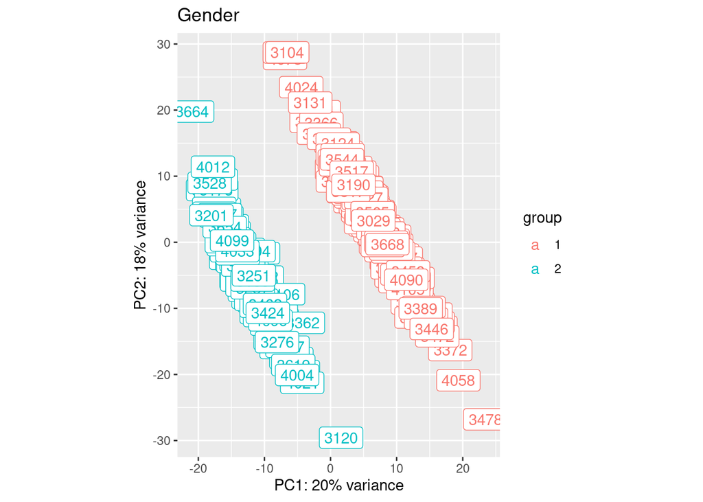

```r
# count normalization
vsd <- vst(dds, blind = F)

# plot PCA coloring samples by gender group
p <- plotPCA(vsd, intgroup = "gen", returnData=F)
p + geom_label(aes(label = colnames(dds))) +
  ggtitle("Gender")  #  batch effect by gender
```

There is a serious batch effect caused by samples geneder… We should remove it before proceeding, since it could seriously bias our results!

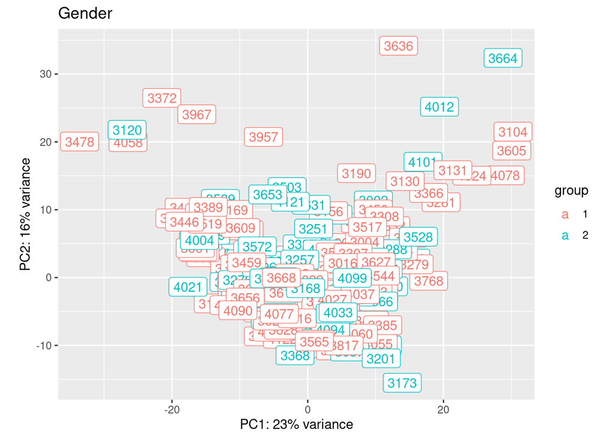

```r
# correct counts to remove batch effect
assay(vsd) <- limma::removeBatchEffect(assay(vsd), vsd$gen)
p <- plotPCA(vsd, intgroup = "gen", returnData=F)
p + geom_label(aes(label = colnames(dds))) +
  ggtitle("Gender")  # batch effect removed
```

Once the batch effect has been removes, we can perform differential expression analysis

```r
dds <- DESeq(dds)
```

```
## -- replacing outliers and refitting for 55 genes
## -- DESeq argument 'minReplicatesForReplace' = 7
## -- original counts are preserved in counts(dds)
```

To visualize the results we can use the results() function of the “DESeq2” package specifying the appropriate contrast. Then, we remove non significant genes (adjusted p-value < 0.1) and we order them by LogFC for a better visualization.

```r
results.putamen.l <- results(dds, contrast = c("PUTAMEN_L.cat", "1", "2"))
results.putamen.l <- results.putamen.l[!is.na(results.putamen.l$padj),]
results.putamen.l <- results.putamen.l[results.putamen.l$padj < .1,]
dim(results.putamen.l)
```

```
## [1] 3332    6
```

```r
results.putamen.l <- results.putamen.l[order(results.putamen.l$log2FoldChange, decreasing = T),]

head(results.putamen.l)
```

```
## log2 fold change (MLE): PUTAMEN_L.cat 1 vs 2
## Wald test p-value: PUTAMEN_L.cat 1 vs 2
## DataFrame with 6 rows and 6 columns
##                    baseMean log2FoldChange     lfcSE      stat      pvalue
##                   <numeric>      <numeric> <numeric> <numeric>   <numeric>
## ENSG00000227674.1  11.19638        2.68652  0.576199   4.66249 3.12410e-06
## ENSG00000206588.1  35.99161        2.19467  0.524950   4.18073 2.90581e-05
## ENSG00000200156.1 382.67974        1.43167  0.340351   4.20645 2.59416e-05
## ENSG00000201031.1   5.13746        1.40239  0.491445   2.85361 4.32253e-03
## ENSG00000200629.1 293.50286        1.34273  0.366592   3.66273 2.49542e-04
## ENSG00000207418.1  14.94759        1.28778  0.440717   2.92202 3.47768e-03
##                        padj
##                   <numeric>
## ENSG00000227674.1 0.0235424
## ENSG00000206588.1 0.0895318
## ENSG00000200156.1 0.0895318
## ENSG00000201031.1 0.0978901
## ENSG00000200629.1 0.0978901
## ENSG00000207418.1 0.0978901
```

Once that the DE genes were retrieved, we are ready to perform Enrichment analysis using the “fgsea” package. As first step we map Ensembl IDs of genes to the EntrezID as required by “fgsea”.

```r
# remove the ID versions from the genes' names
ensembl.ids <- rownames(results.putamen.l)
ensembl.ids <- sapply(
  rownames(results.putamen.l),
  function(x){
    unlist(strsplit(x, fixed = T, split = "."))[1]
  }
)
names(ensembl.ids) <- NULL  # remove old names

# mapping
entrez.ids <- select(
  org.Hs.eg.db,
  keys = ensembl.ids,
  columns = "ENTREZID",
  keytype = "ENSEMBL"
)
entrez.ids <- entrez.ids[!duplicated(entrez.ids$ENSEMBL),]  # remove duplicates
entrez.ids <- entrez.ids[!is.na(entrez.ids$ENTREZID),]  # remove NAs
results.putamen.l <- results.putamen.l[entrez.ids$ENSEMBL,]  # remove unmapped genes

# change the names of the genes
rownames(results.putamen.l) <- entrez.ids$ENTREZID
head(results.putamen.l)
```

```
## log2 fold change (MLE): PUTAMEN_L.cat 1 vs 2
## Wald test p-value: PUTAMEN_L.cat 1 vs 2
## DataFrame with 6 rows and 6 columns
##             baseMean log2FoldChange     lfcSE      stat      pvalue      padj
##            <numeric>      <numeric> <numeric> <numeric>   <numeric> <numeric>
## 144766       11.1964        2.68652  0.576199   4.66249 3.12410e-06 0.0235424
## 26866        35.9916        2.19467  0.524950   4.18073 2.90581e-05 0.0895318
## 26832       382.6797        1.43167  0.340351   4.20645 2.59416e-05 0.0895318
## 106481710   293.5029        1.34273  0.366592   3.66273 2.49542e-04 0.0978901
## 6084      22277.0778        1.15283  0.355939   3.23883 1.20022e-03 0.0978901
## 26871       500.6501        1.05892  0.321565   3.29302 9.91182e-04 0.0978901
```

Now, we can perform Enrichment analysis. First, we order genes by LogFC. Then, we retrieve the Reactome gene sets using the `reactomePathways()` function and then we run `fgsea()`. At the end we filter out non significant pathways (adjusted p-value < 0.1)

```r
# construct a vector containing the LogFC of each gene
lfc <- results.putamen.l$log2FoldChange
names(lfc) <- rownames(results.putamen.l)

# recover pathways
pathways <- reactomePathways(names(lfc))
enr.fgsea.reactome <- fgsea(
  pathways,
  lfc,
  nPermSimple = 1000000,
  eps = 0,
  minSize = 5
)
# subset to signifcant pathways (q-value < 0.1)
enr.fgsea.reactome <- enr.fgsea.reactome[enr.fgsea.reactome$padj < .1,]
head(as.data.frame(enr.fgsea.reactome))
```

```
##                                                                                                    pathway
## 1                                                        APC/C-mediated degradation of cell cycle proteins
## 2                                                              APC/C:Cdc20 mediated degradation of Securin
## 3                                                     APC/C:Cdc20 mediated degradation of mitotic proteins
## 4 APC/C:Cdh1 mediated degradation of Cdc20 and other APC/C:Cdh1 targeted proteins in late mitosis/early G1
## 5  APC:Cdc20 mediated degradation of cell cycle proteins prior to satisfation of the cell cycle checkpoint
## 6                                                              AUF1 (hnRNP D0) binds and destabilizes mRNA
##           pval         padj   log2err        ES      NES size
## 1 2.018589e-06 9.229927e-06 0.6272567 0.7359244 2.787334   11
## 2 3.778570e-09 2.772416e-08 0.7614608 0.8856209 3.209803   10
## 3 2.018589e-06 9.229927e-06 0.6272567 0.7359244 2.787334   11
## 4 3.778570e-09 2.772416e-08 0.7614608 0.8856209 3.209803   10
## 5 2.018589e-06 9.229927e-06 0.6272567 0.7359244 2.787334   11
## 6 1.125864e-10 1.869526e-09 0.8390889 0.8859426 3.355532   11
##                                                        leadingEdge
## 1       5685, 5702, 5699, 5720, 5688, 5686, 5713, 5700, 5719, 9861
## 2       5685, 5702, 5699, 5720, 5688, 5686, 5713, 5700, 5719, 9861
## 3       5685, 5702, 5699, 5720, 5688, 5686, 5713, 5700, 5719, 9861
## 4       5685, 5702, 5699, 5720, 5688, 5686, 5713, 5700, 5719, 9861
## 5       5685, 5702, 5699, 5720, 5688, 5686, 5713, 5700, 5719, 9861
## 6 5685, 3312, 5702, 5699, 5720, 5688, 5686, 5713, 5700, 5719, 9861
```

To export the pathways retrieved we can use the fwrite() function of the package “data.table”

```r
# store results
fwrite(
  as.data.frame(enr.fgsea.reactome),
  "../resultsRNAseq/Fgsea_PutamenL_Reactome.csv",
  sep = "\t",
  sep2 = c("", " ", "")
)
```

We can use the same code for all the features we considered in our study. Therefore, we will get a CSV file with potentially perturbed pathways for each neuroimaging feature we considered.

And now?

Let’s combine the results obtained from GWAS, DE and Enrichment analyses!

In our example we will focus on 11:60750247 SNP (found during Individual View with DaTscan).

First, we search of the SNP is mapped within or close to any gene. To do this let’s use UCSC genome browser (https://genome.ucsc.edu/).

Our SNP (rs79761481 with RsID) maps within CD6 gene! That is a good starting point. We now explore if there are any gene interacting with CD6. Let’s recover CD6 PPI!

To do this we will use STRINGdb R package:

```r
string_db <- STRINGdb$new(
  version = "11", species = 9606
)
```

```
## WARNING: Score threshold is not specified. We will be using medium stringency cut-off of 400.
```

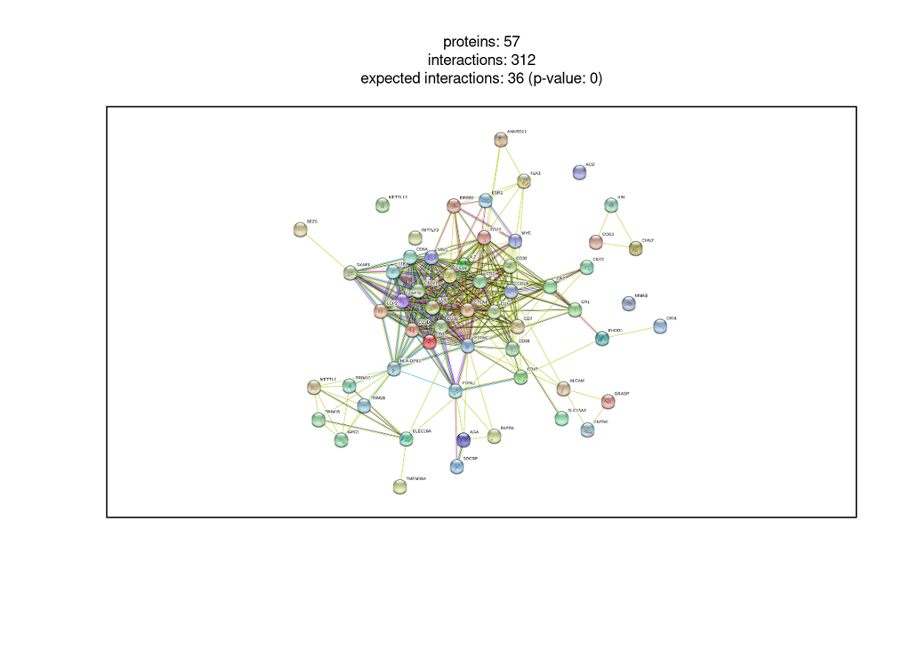

```r
protein <-  string_db$mp("CD6")
neig <- string_db$get_neighbors(protein)
string_db$plot_network(neig)
```

As we can see CD6 gene has many direct and indirect interactors. Let’s the retrieve their names:

```r
neig.genes <- sapply(
  neig,
  function(x){
    base <- "https://string-db.org/api/tsv/get_string_ids?"
    id <- paste0("identifiers=", x, "%0dcdk2&")
    species <-  "species=9606"
    url <- paste0(base,id,species)
    res <- GET(url)
    con <- rawToChar(res$content)
    df  <- read.table(text = con, sep = "\t", header = TRUE)
    return(df$preferredName[1])
  }
)
names(neig.genes) <- NULL
neig.genes
```

```
##  [1] "CD4"      "LCP2"     "CHN2"     "CD38"     "IL2"      "SLC15A3"
##  [7] "FHOD1"    "SDCBP"    "AGA"      "ZAP70"    "CD27"     "ERBB2"
## [13] "GRASP"    "COG1"     "CD3D"     "ANKRD11"  "CTLA4"    "ALCAM"
## [19] "CD7"      "SEZ6"     "KLK3"     "METTL1"   "CD28"     "TMEM39A"
## [25] "PAPPA"    "RIPPLY3"  "LCK"      "SKAP1"    "CD5"      "CD3E"
## [31] "CD247"    "METTL13"  "CD47"     "CR1"      "CR2"      "CD2"
## [37] "CD58"     "TRIM15"   "GPC5"     "KIN"      "CD72"     "CD8A"
## [43] "CLEC16A"  "TRIM10"   "ITK"      "PTPRJ"    "ESR1"     "CNTN6"
## [49] "HLA-DPB1" "TRIM26"   "PTPRC"    "CR1L"     "CD19"     "MMAB"
## [55] "VAV1"     "MYC"      "ACD"
```

Now that we have CD6 interactors names, we can search the pathways in which they participate. Let’s go to Reactiome database (https://reactome.org/).

Once we downloaded the list of CD6 interactors pathways, we can intersect the recovered pathways with those found during our enrichment analyses.

```r
files = list.files(path="../tutorialICHI/resultsRNAseq/DATSCAN", pattern="*.csv", full.names = T)
files = c(files, list.files(path="../tutorialICHI/resultsRNAseq/MRI", pattern="*.csv", full.names = T) )

for (react in c("/resultsRNAseq/CD6_PPI_Reactome_Pathways.csv")){
  cat("******* PPI of: ", strsplit(react,"_")[[1]][1]," *******")
  reactome = read.csv(paste(getwd(),react, sep = ""), header=T, sep=",")
  reactome = reactome[reactome$Entities.FDR<0.1,]
  if(nrow(reactome)==0){break}
  for (i in files){
   pheno = strsplit(i,"_")[[1]][2]
   cat("\nPheno: ", pheno, "\n")
   df = read.csv(i,sep="\t")[,c(1,8)]
   print((intersect(reactome$Pathway.name,df$pathway)))
   cat("\n\n")
 }
}
```

```
## ******* PPI of:  /resultsRNAseq/CD6  *******
## Pheno:  CaudateR
## [1] "Innate Immune System"
##
##
##
## Pheno:  PutamenL
## [1] "TCR signaling"                       "Downstream TCR signaling"
## [3] "Transcriptional regulation by RUNX1" "Innate Immune System"
## [5] "Host Interactions of HIV factors"
##
##
##
## Pheno:  PhareaL
## [1] "Costimulation by the CD28 family"
## [2] "The role of Nef in HIV-1 replication and disease pathogenesis"
## [3] "Nef-mediates down modulation of cell surface receptors by recruiting them to clathrin adapters"
## [4] "Host Interactions of HIV factors"
## [5] "Interleukin-2 signaling"
## [6] "Neutrophil degranulation"
## [7] "ESR-mediated signaling"
##
##
##
## Pheno:  phvolL
## character(0)
```

We found 13 pathways in common!

Therefore, we can conclude that SNP rs79761481 can potentially perturb these pathways and this pobservation has also been confirmed by transcriptomic data.

Moreover, the found pathways have been linked to PD in literature (Kannarkat GT *et al.*, Journal of Parkinson’s disease 2013; Xie L *et al.*, Journal of neuroinflammation 2010; Hu Y *et al.*, Frontiers in neurology 2020).